# Face Recognition Technology Evaluation (FRTE) 1:N Identification

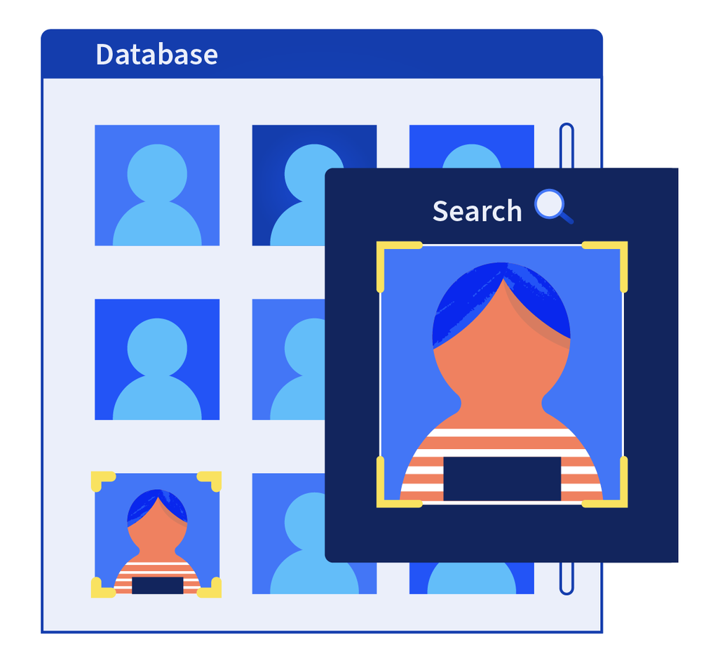

Credit: Natasha Hanacek/NIST

[Latest Report](https://pages.nist.gov/frvt/reports/1N/frvt_1N_report.pdf) | [Participation Agreement](https://pages.nist.gov/frvt/agreements/frvt_participation_agreement.pdf) | [API](https://pages.nist.gov/frvt/api/FRVT_IREX_ongoing_1N_api.pdf) | [Validation](https://github.com/usnistgov/frvt) | [Encryption](https://www.nist.gov/itl/iad/image-group/products-and-services/encrypting-softwaredata-transmission-nist) | [Submit](https://pages.nist.gov/frvt/html/frvt_submission_form.html)

**[NOTE]**The duration values for algorithms submitted since 2025-09-04 are provisional. From that date NIST ran all algorithms on a more recent Linux operating system (OS). The durations may be revised after we conclude our investigation into why numeric software is slower on identical hardware equipped with the new OS.

[last updated: 2026-09-04]

|  | 2018 | 2019 | 2020 | 2021 | 2022 | 2023 | 2024 | 2025 | 2026 | Total |
| --- | --- | --- | --- | --- | --- | --- | --- | --- | --- | --- |
| Number of algorithms | 209 | 31 | 23 | 76 | 57 | 81 | 78 | 77 | 63 | 695 |
| Number of unique developers | 53 | 25 | 20 | 52 | 41 | 56 | 60 | 62 | 52 | 219 |

[last updated: 2026-09-03]

###### Identification (T>0) by Developer

### Identification Performance

The table below shows False Negative Identification Rates (FNIR) for the most accurate algorithm from each developer. Most accurate is defined by the lowest mean within-developer rank, with the mean taken across the eight columns of the table. The FNIR values are computed at the threshold that limits the False Positive Identification Rate (FPIR) to 0.003. FNIR is the proportion of mated searches failing to return the mate above threshold. FPIR is the proportion of non-mated searches producing one or more candidates above threshold. The threshold is set for each algorithm and each column separately. The use of thresholding supports use of face recognition in making mostly automated decisions e.g. for access into aircraft. The first row in the header shows the type of image enrolled in the gallery; the second row shows the search image type; the third row shows the number of persons in the gallery. The images are described in the section 2 of the report. In all cases, each person is enrolled with one image only.

The values in blue use the FRTE API call (introduced 2022-02-14) that allows the algorithm to produce templates from multiple faces in one image, which occurs in approximately 3% of border images and 7% of kiosk images. The handling and accuracy consequences of this are detailed on this [slide](https://pages.nist.gov/frvt/html/slides/multiple_faces_single_image.pdf).

[interactive table not shown]

###### Investigation (R=1, T=0) by Developer

### Investigation Performance

The table below shows False Negative Identification Rates (FNIR) for the case where the threshold is set to zero and the algorithm returns a fixed number (50) of candidates. FNIR is the proportion of mated searches for which the algorithm does not place the correct candidate at rank 1. The use of face recognition without a threshold supports investigate uses where it is assumed and necessary that a human will be used to review the candidates returned from each search. For mated-searches the human is tasked with finding the correct mate; for non-mated searches the reviewer must reject all the candidates. The first row in the header shows the type of image enrolled in the gallery; the second row shows the search image type; the third row shows the number of persons in the gallery. In all cases, each person is enrolled with one image only.

[interactive table not shown]

###### Identification (T>0) by Algorithm

### Identification Performance

The table below shows False Negative Identification Rates (FNIR) for the case where a threshold is set to limit to the False Positive Identification Rate (FPIR) to 0.003. FNIR is the proportion of mated searches failing to return the mate above threshold. FPIR is the proportion of non-mated searches producing one or more candidates above threshold. The threshold is set for each algorithm and each column separately. The use of thresholding supports use of face recognition in making mostly automated decisions e.g. for access into facility. The first row in the header shows the type of image enrolled in the gallery; the second row shows the search image type; the third row shows the number of persons in the gallery. The images are described in the section 2 of the report. In all cases, each person is enrolled with one image only.

The values in blue correspond to a change in the FRTE API on 2022-02-14 that allows the algorithm to detect and produce templates from multiple faces in one image, which occurs in approximately 3% of border images and 7% of kiosk images. The handling and accuracy consequences of this are detailed on this [slide](https://pages.nist.gov/frvt/html/slides/multiple_faces_single_image.pdf).

[interactive table not shown]

###### Investigation (R=1, T=0) by Algorithm

### Investigation Performance

The table below shows False Negative Identification Rates (FNIR) for the case where the threshold is set to zero and the algorithm returns a fixed number (50) of candidates. FNIR is the proportion of mated searches for which the algorithm does not place the correct candidate at rank 1. The use of face recognition without a threshold supports investigate uses where it is assumed and necessary that a human will be used to review the candidates returned from each search. For mated-searches the human is tasked with finding the correct mate; for non-mated searches the reviewer must reject all the candidates. The first row in the header shows the type of image enrolled in the gallery; the second row shows the search image type; the third row shows the number of persons in the gallery. In all cases, each person is enrolled with one image only.

[interactive table not shown]

###### Demographics: False Positive Dependence

False positives occur when searches return wrong identities. Such outcomes have application-dependent consequences, which can be serious.

The table shows false positive identification rates (FPIR), the fraction of searches that should not return gallery entries above a threshold, but do. The threshold is set for each algorithm to give a FPIR of 0.002 (1 in 500) or less on searches of women born in Eastern Europe. A cell is shaded by how much larger FPIR is than that: yellow if FPIR is 20 times larger; pink if FPIR is 40 times larger; and dark pink if FPIR is 80 times larger.

In columns three and four are inequity summaries required by ISO/IEC 19795-10:2024: The [Gini coefficient](https://mathworld.wolfram.com/GiniCoefficient.html) is on the range [0,1]; MXOG is the maximum of eight FPIR values divided by their geometric mean. For both measures lower values are better.

**For an explanation of this trial and the entire topic of demographic effects in one-to-many searches, see [this presentation](https://pages.nist.gov/frvt/html/slides/demographics_1N.pdf).**

| Algorithm | Date | GINI | MXOG | E-AsiaF | E-EuropeF | S-AsiaF | W-AfricaF | E-AsiaM | E-EuropeM | S-AsiaM | W-AfricaM | V_1 | V_2 | V_3 | V_4 | V_5 | V_6 | V_7 | V_8 |
| --- | --- | --- | --- | --- | --- | --- | --- | --- | --- | --- | --- | --- | --- | --- | --- | --- | --- | --- | --- |
| afrengine-002 | 2024_07_25 | 0.67(119) | 8.78(102) | 0.0832(85) | 0.0020(109) | 0.0559(81) | 0.0289(72) | 0.0108(75) | 0.0005(86) | 0.0112(94) | 0.0042(65) | 41.59999999999999 | 1 | 27.95 | 14.45 | 5.4 | 0.25 | 5.6 | 2.1 |
| aigroup-000 | 2026_05_12 | 0.59(38) | 6.97(47) | 0.1228(145) | 0.0019(23) | 0.0969(162) | 0.1339(177) | 0.0228(158) | 0.0004(68) | 0.0267(174) | 0.0221(172) | 64.63157894736842 | 1 | 51 | 70.47368421052632 | 12 | 0.2105263157894737 | 14.05263157894737 | 11.63157894736842 |
| aize-006 | 2026_04_08 | 0.72(161) | 12.85(167) | 0.1385(158) | 0.0020(109) | 0.0939(160) | 0.0411(119) | 0.0184(134) | 0.0003(14) | 0.0110(89) | 0.0030(48) | 69.25 | 1 | 46.95 | 20.55 | 9.2 | 0.15 | 5.5 | 1.5 |
| alchera-007 | 2024_06_17 | 0.65(75) | 7.67(60) | 0.1049(115) | 0.0019(23) | 0.1006(164) | 0.0434(131) | 0.0164(116) | 0.0007(140) | 0.0174(157) | 0.0070(142) | 55.21052631578947 | 1 | 52.94736842105263 | 22.84210526315789 | 8.631578947368421 | 0.3684210526315789 | 9.157894736842104 | 3.684210526315789 |
| allgovision-005 | 2026_03_12 | 0.64(59) | 8.66(90) | 0.1445(161) | 0.0019(23) | 0.1060(169) | 0.0584(166) | 0.0240(162) | 0.0005(86) | 0.0238(171) | 0.0126(167) | 76.05263157894737 | 1 | 55.78947368421053 | 30.73684210526316 | 12.63157894736842 | 0.2631578947368421 | 12.52631578947368 | 6.631578947368421 |
| aratek-001 | 2024_04_18 | 0.65(76) | 8.48(86) | 0.1090(123) | 0.0020(109) | 0.0743(112) | 0.0471(145) | 0.0161(112) | 0.0005(99) | 0.0151(140) | 0.0078(143) | 54.5 | 1 | 37.15 | 23.55 | 8.049999999999999 | 0.25 | 7.55 | 3.9 |
| aware-007 | 2023_11_27 | 0.29(9) | 1.83(4) | 0.0004(1) | 0.0020(109) | 0.0028(13) | 0.0030(7) | 0.0005(3) | 0.0033(177) | 0.0033(20) | 0.0028(46) | 0.2 | 1 | 1.4 | 1.5 | 0.25 | 1.65 | 1.65 | 1.4 |
| canon-003 | 2023_09_05 | 0.35(16) | 3.15(22) | 0.0025(15) | 0.0020(109) | 0.0033(16) | 0.0089(33) | 0.0022(27) | 0.0012(163) | 0.0032(18) | 0.0034(57) | 1.25 | 1 | 1.65 | 4.45 | 1.1 | 0.6 | 1.6 | 1.7 |
| clearviewai-000 | 2021_11_12 | 0.59(39) | 6.01(34) | 0.0573(71) | 0.0020(109) | 0.0338(62) | 0.0437(135) | 0.0105(74) | 0.0005(99) | 0.0093(73) | 0.0080(146) | 28.65 | 1 | 16.9 | 21.85 | 5.25 | 0.25 | 4.649999999999999 | 4 |
| clearviewai-001 | 2024_02_16 | 0.59(40) | 6.89(45) | 0.0855(88) | 0.0019(5) | 0.0645(93) | 0.0559(160) | 0.0143(98) | 0.0004(31) | 0.0142(125) | 0.0130(169) | 45 | 1 | 33.94736842105263 | 29.42105263157895 | 7.526315789473684 | 0.2105263157894737 | 7.473684210526316 | 6.842105263157895 |

[output cut: 168 more lines]

###### Demographics: False Negative Dependence

The tab shows false negative identification rates (FNIR), the proportion of searches of given demographic group for which the correct mated identity is not returned by the algorithm above a threshold. Th threshold is set for each algorithm to give FPIR = 0.002 on women born in E. Europe. The threshold is is used across all demographic groups - this is an operational necessity as demographic group membership of the subject is not usually known during capture.

| Algorithm | Date | GINI | MXOG | E-AsiaF | E-EuropeF | S-AsiaF | W-AfricaF | E-AsiaM | E-EuropeM | S-AsiaM | W-AfricaM |
| --- | --- | --- | --- | --- | --- | --- | --- | --- | --- | --- | --- |
| afrengine-002 | 2024_07_25 | 0.23(50) | 2.05(107) | 0.0093(154) | 0.0076(156) | 0.0182(167) | 0.0117(150) | 0.0065(161) | 0.0066(162) | 0.0099(163) | 0.0060(142) |
| aigroup-000 | 2026_05_12 | 0.23(51) | 1.66(29) | 0.0037(117) | 0.0050(136) | 0.0056(129) | 0.0047(106) | 0.0017(112) | 0.0032(138) | 0.0024(117) | 0.0028(104) |
| aize-006 | 2026_04_08 | 0.35(158) | 2.85(167) | 0.0222(169) | 0.0247(170) | 0.0151(164) | 0.0492(170) | 0.0089(167) | 0.0114(166) | 0.0108(164) | 0.0177(166) |
| alchera-007 | 2024_06_17 | 0.23(49) | 2.02(101) | 0.0039(122) | 0.0041(127) | 0.0079(142) | 0.0051(110) | 0.0027(131) | 0.0025(124) | 0.0042(144) | 0.0030(106) |
| allgovision-005 | 2026_03_12 | 0.14(5) | 1.40(3) | 0.0166(167) | 0.0164(166) | 0.0217(169) | 0.0232(162) | 0.0125(169) | 0.0124(167) | 0.0143(168) | 0.0183(167) |
| aratek-001 | 2024_04_18 | 0.24(72) | 2.12(122) | 0.0060(145) | 0.0075(155) | 0.0167(165) | 0.0105(148) | 0.0051(155) | 0.0054(159) | 0.0090(161) | 0.0076(153) |
| aware-007 | 2023_11_27 | 0.51(178) | 3.76(176) | 0.0503(173) | 0.0100(163) | 0.0181(166) | 0.0516(171) | 0.0113(168) | 0.0029(128) | 0.0078(159) | 0.0106(161) |
| canon-003 | 2023_09_05 | 0.39(170) | 2.55(161) | 0.0044(125) | 0.0015(53) | 0.0031(83) | 0.0038(96) | 0.0011(70) | 0.0007(39) | 0.0010(56) | 0.0013(23) |
| clearviewai-000 | 2021_11_12 | 0.29(127) | 2.07(111) | 0.0028(103) | 0.0026(104) | 0.0034(100) | 0.0045(105) | 0.0014(95) | 0.0011(74) | 0.0016(96) | 0.0020(72) |
| clearviewai-001 | 2024_02_16 | 0.26(101) | 1.91(79) | 0.0020(58) | 0.0016(56) | 0.0029(68) | 0.0024(50) | 0.0009(53) | 0.0008(51) | 0.0010(44) | 0.0016(34) |

[output cut: 168 more lines]

### Resources Used

The table gives data on various aspects of computational cost and storage. Algorithms submitted to FRTE implement NIST’s application programming interface (API). We measure the duration of all function calls using the C++ std::chrono::high resolution clock on an unloaded server-class machine. The table below includes durations of the template generation, finalization, search calls. In addition the size of the algorithm is reported in two parts: the recognition models, and the libraries.

[interactive table not shown]

All prior Ongoing FRTE 1:N reports can be accessed from [here](https://github.com/usnistgov/frvt/tree/nist-pages/reports/1N).

To participate in this evaluation, developers need to submit a participation agreement to NIST, wrap their software behind the published C++ API, run their libraries through the provided validation package (which creates a submission package), encrypt the package, and provide a download link for the encrypted submission package. More details are provided below.

### Participation Agreement

FRTE is conducted by NIST, an agency of the United States Government. Participation is free of charge. FRTE is open to a global audience of face recognition developers. All organizations who seek to participate in FRTE must sign all pages of this [Participation Agreement](https://pages.nist.gov/frvt/agreements/frvt_participation_agreement.pdf) and submit it with their algorithm submission using the [FRTE Submission Form](https://pages.nist.gov/frvt/html/frvt_submission_form.html). [last update: 2023-07-03]

### API Document

A new [API document](https://pages.nist.gov/frvt/api/FRTE_IREX_ongoing_1N_api.pdf) has been published. All FRTE APIs reference the supporting [FRTE General Evaluation Specifications](https://pages.nist.gov/frvt/api/FRVT_common.pdf), which includes hardware and operating system environment, software requirements, reporting, and common data structures that support the APIs. Developers must ensure that their submission conforms to the API specifications. [last update: 2023-04-06]

### Validation

An updated [validation package](https://github.com/usnistgov/frvt) has been published. All participants must run their software through the validation package prior to submission. The purpose of validation is to ensure consistent algorithm output between your execution and NIST’s execution. [last update: 2023-04-28]

### Encryption

All submissions must be properly encrypted and signed before transmission to NIST. This must be done according to these [instructions](https://www.nist.gov/system/files/documents/2021/10/25/nist_encryption.pdf) using the FRTE Ongoing public key linked from this [page](https://www.nist.gov/itl/iad/image-group/products-and-services/encrypting-softwaredata-transmission-nist). Participants must email their public key to NIST. The participant’s public key must correspond to the participant’s public-key fingerprint provided on the signed Participation Application. [last update: 2017-11-20]

### Submission

All algorithm submissions must be submitted through the [FRTE Submission Form](https://pages.nist.gov/frvt/html/frvt_submission_form.html), which requires encrypted files be provided as a download link from a generic http server (e.g., Google Drive). We cannot accept Dropbox links. NIST will not register, or establish any kind of membership, on the provided website. Participants can submit their algorithm(s), participation agreement, and GPG key at the same time via the submission form. [last update: 2023-07-03]

Participants must subscribe to the FRTE mailing list to receive emails when new reports are published or announcements are made.

Inquiries and comments may be submitted to frvt@nist.gov.

Subscribe to the FRTE mailing list to receive emails when announcements or updates are made.

## Related NIST Projects

##### [Ongoing Face Evaluations](https://www.nist.gov/programs-projects/face-recognition-vendor-test-frvt-ongoing)

## FRTE Projects

##### [FRTE 1:1 Verification](https://pages.nist.gov/frvt/html/frvt11.html)

##### [FRTE 1:N Identification](https://pages.nist.gov/frvt/html/frvt1N.html)

##### [FRTE Demographic Effects](https://pages.nist.gov/frvt/html/frvt_demographics.html)

##### [FRTE Face Mask Effects](https://pages.nist.gov/frvt/html/frvt_facemask.html)

##### [FRTE Paperless Travel](https://pages.nist.gov/frvt/html/frvt_paperless_travel.html)

##### [FRTE Twins Demonstration](https://pages.nist.gov/frvt/html/frvt_twins_demonstration.html)

##### [FRTE FIVE](https://pages.nist.gov/frvt/html/frte_five.html)

## FATE Projects

##### [FATE MORPH](https://pages.nist.gov/frvt/html/frvt_morph.html)

##### [FATE Quality](https://pages.nist.gov/frvt/html/frvt_quality.html)

##### [FATE PAD](https://pages.nist.gov/frvt/html/frvt_pad.html)

##### [FATE Age Estimation & Verification](https://pages.nist.gov/frvt/html/frvt_age_estimation.html)